# 4. Perguntas

Jonas Coelho

27/04/2021

# Introdução

Carregando a base:

```r
load("../dados/sp_2019.RData")
load("../dados/escolas_com_dados.RData")
```

Relembrando a estrutura:

```r
head(sp_2019)
```

| ano | mes | nome | codigo_do_local_de_exercicio | local_de_exercicio | carga_horaria | tipo_categoria | categoria_profissional | situacao_profissional | salario_ou_vencimento_basico_r | com_parcela_minima_de_60_percent_do_fundeb | com_parcela_minima_de_40_percent_do_fundeb_b | outras_receitas_c | total_a_b_c |
| --- | --- | --- | --- | --- | --- | --- | --- | --- | --- | --- | --- | --- | --- |
| 2019 | Fevereiro | AÃ¿UNCIARA AIZAWA SILVA | 000000206095 | EMEF VIRGILIO DE MELLO FRANCO | 23 | Profissionais do magistério | Docente habilitado em curso de licenciatura plena | Efetivo | 2.739,58 | 3.471,53 | 0,00 | 744,11 | 4.215,64 |
| 2019 | Fevereiro | ABEL APARECIDO DE ALMEIDA | 000000352726 | EMEF CARLOS CORREA MASCARO PROF | 30 | Profissionais do magistério | Docente habilitado em curso de licenciatura plena | Efetivo | 3.652,82 | 3.843,98 | 0,00 | 744,11 | 4.588,09 |
| 2019 | Fevereiro | ABEL BRUDER DOS SANTOS | 000000204248 | EMEF OLINDA MENEZES SERRA VIDAL PROFA | 23 | Profissionais do magistério | Docente habilitado em curso de licenciatura plena | Efetivo | 2.739,58 | 2.824,76 | 0,00 | 427,24 | 3.252,00 |
| 2019 | Fevereiro | ABEL COSTA | 000000539681 | CEI DIRET MARIA AUGUSTA DE PAULA PROFA | 30 | Profissionais do magistério | Docente habilitado em curso de pedagogia | Efetivo | 6.045,24 | 8.033,63 | 0,00 | 1.047,48 | 9.081,11 |
| 2019 | Fevereiro | ABELNILDE SANTANA DA SILVA CHAVES | 000002927851 | CEMEI VILA DO SOL I | 30 | Profissionais do magistério | Docente habilitado em curso de pedagogia | Efetivo | 3.652,82 | 3.761,70 | 0,00 | 744,11 | 4.505,81 |
| 2019 | Fevereiro | ABGAIL VITAL RAMOS DUARTE | 000000205166 | EMEI ALAIDE BUENO RODRIGUES PROFA | 30 | Profissionais do magistério | Docente habilitado em curso de pedagogia | Efetivo | 6.045,24 | 7.082,12 | 0,00 | 374,85 | 7.456,97 |

# 1. Foram só professores concursados?

Não temos um referencial específico para isso, vamos checar nas demais colunas

```r
sp_2019 %>%
  distinct(tipo_categoria, categoria_profissional)
```

| tipo_categoria | categoria_profissional |
| --- | --- |
| Profissionais do magistério | Docente habilitado em curso de licenciatura plena |
| Profissionais do magistério | Docente habilitado em curso de pedagogia |
| Profissionais do magistério | Profissionais em efetivo exercício no âmbito da educação infantil e ensino fundamental. |
| Profissionais do magistério | Docente habilitado em curso de nível médio |
| Profissionais do magistério | Profissionais não habilitados, porém autorizados a exercer a docência em caráter precário e provisório na educação infantil e nos anos iniciais do ensino fundamental |

Os dados fornecidos só nos apontam a qualificação dos profissionais. Entretanto, como será visto a seguir, os profissionais listados estão associados à secretaria de educação, o que indica possivelmente que são concursados.

# 2. O banco tem só salários ou a classificação na carreira?

Como visto no ponto 1, não há classificação da carreira, apenas nível de habilitação do professor e o salário.

# 3. Foram separados os vencimentos de profissionais com mais de um cargo?

Vamos antes verificar se há casos assim.

```r
duplicatas <- sp_2019 %>%
  mutate(nome_cod = paste0(nome, codigo_do_local_de_exercicio, ano, mes)) %>%
  group_by(nome_cod) %>%
  filter(n() > 1) %>%
  ungroup()
```

```r
duplicatas %>%
  summarise(nomes_distintos = n_distinct(nome), entradas_distintas = n_distinct(nome_cod))
```

| nomes_distintos | entradas_distintas |
| --- | --- |
| 2860 | 28608 |

Há 2.860 funcionários com dois (ou mais) pagamentos na mesma escola e no mesmo mês do mesmo ano. Para descobrir o que está acontecendo, podemos ter uma pista ao importar os dados obtidos do Portal de Transparência municipal de São Paulo ( http://transparencia.prefeitura.sp.gov.br/funcionalismo/ ). Entretanto, esse arquivo não informa quando foi gerado. Por isso vamos, vamos usar o portal de Dados Abertos para obter o csv referente a dezembro de 2019, o último mês analisado por nós. http://dados.prefeitura.sp.gov.br/dataset/remuneracao-servidores-prefeitura-de-sao-paulo

```r
dados_abertos <- read_delim("../dados/remuneracao12-2019atiliminar20200103.csv",
    ";", escape_double = FALSE, locale = locale(decimal_mark = ",",
        encoding = "ISO-8859-1"), trim_ws = TRUE) %>%
  janitor::clean_names()
```

Agora vamos dar um merge

```r
merged <- duplicatas %>%
     filter(ano == 2019 & mes == 'Dezembro') %>% # mesmo mês do arquivo baixado
     left_join(dados_abertos, by = c('nome' = 'nome_completo'))
```

Vamos ver os cargos que aparecem agora

```r
merged %>%
  distinct(cargo_base)
```

| cargo_base |
| --- |
| PROFESSOR ED INFANTIL E ENS FUNDAMENTAL CAT 3 |
| PROFESSOR ENSINO FUNDAMENTAL II E MEDIO CAT 3 |
| NA |
| COORDENADOR PEDAGOGICO |
| PROFESSOR EDUCACAO INFANTIL CAT 3 |
| ASSISTENTE DE GESTAO DE POLITICAS PUBLICAS NIVEL I |
| PROFESSOR ED INFANTIL E ENS FUNDAMENTAL CAT 1 |
| AUXILIAR TECNICO DE EDUCACAO CAT 1 |
| DIRETOR DE ESCOLA |
| AGENTE ESCOLAR |

[output cut: 18 more lines]

É possível notar que há cargos administrativos (Diretor de escola, Coordenardor pedagogico). Vamos ver a remuneração desses:

```r
merged %>%
  filter(cargo_base == 'DIRETOR DE ESCOLA') %>%
  head()
```

| ano | mes | nome | codigo_do_local_de_exercicio | local_de_exercicio | carga_horaria | tipo_categoria | categoria_profissional | situacao_profissional | salario_ou_vencimento_basico_r | com_parcela_minima_de_60_percent_do_fundeb | com_parcela_minima_de_40_percent_do_fundeb_b | outras_receitas_c | total_a_b_c | nome_cod | excecao | cargo_base | cargo_em_comissao | remuneracao_do_mes | demais_elementos_da_remuneracao | remuneracao_bruta | unidade | tp_log | logadrouro | numero | complemento | jornada |
| --- | --- | --- | --- | --- | --- | --- | --- | --- | --- | --- | --- | --- | --- | --- | --- | --- | --- | --- | --- | --- | --- | --- | --- | --- | --- | --- |
| 2019 | Dezembro | ANA CRISTINA DA SILVA | 000000202876 | EMEF CIDADE DE OSAKA | 23 | Profissionais do magistério | Docente habilitado em curso de licenciatura plena | Efetivo | 3.370,04 | 8.556,69 | 0,00 | 462,80 | 9.019,49 | ANA CRISTINA DA SILVA0000002028762019Dezembro | NA | DIRETOR DE ESCOLA | NA | 14249.11 | 4060.04 | 18309.15 | EMEI JARDIM LUCELIA | Rua | NELIA ANDRE | NA | S/N | JBE |
| 2019 | Dezembro | ANA CRISTINA DA SILVA | 000000202876 | EMEF CIDADE DE OSAKA | 30 | Profissionais do magistério | Docente habilitado em curso de licenciatura plena | Efetivo | 4.785,29 | 14.931,70 | 0,00 | 481,82 | 15.413,52 | ANA CRISTINA DA SILVA0000002028762019Dezembro | NA | DIRETOR DE ESCOLA | NA | 14249.11 | 4060.04 | 18309.15 | EMEI JARDIM LUCELIA | Rua | NELIA ANDRE | NA | S/N | JBE |
| 2019 | Dezembro | ELAINE CRISTINA DUARTE | 000000205835 | EMEI CARVALHO PINTO GOV | 23 | Profissionais do magistério | Docente habilitado em curso de pedagogia | Efetivo | 4.617,41 | 11.564,79 | 0,00 | 607,94 | 12.172,73 | ELAINE CRISTINA DUARTE0000002058352019Dezembro | NA | DIRETOR DE ESCOLA | NA | 14051.51 | 2860.78 | 16912.29 | EMEF EDGARD CARONE | Rua | ELISA DINA | 293 | NA | JBE |
| 2019 | Dezembro | ELAINE CRISTINA DUARTE | 000000205835 | EMEI CARVALHO PINTO GOV | 30 | Profissionais do magistério | Docente habilitado em curso de pedagogia | Efetivo | 5.427,98 | 14.661,31 | 0,00 | 0,00 | 14.661,31 | ELAINE CRISTINA DUARTE0000002058352019Dezembro | NA | DIRETOR DE ESCOLA | NA | 14051.51 | 2860.78 | 16912.29 | EMEF EDGARD CARONE | Rua | ELISA DINA | 293 | NA | JBE |
| 2019 | Dezembro | JOSE CLAUDIO DA SILVA | 000000202800 | EMEF PAULO PRADO | 23 | Profissionais do magistério | Docente habilitado em curso de licenciatura plena | Efetivo | 4.617,41 | 10.145,63 | 0,00 | 2.705,55 | 12.851,18 | JOSE CLAUDIO DA SILVA0000002028002019Dezembro | NA | DIRETOR DE ESCOLA | NA | 10377.61 | 2623.17 | 13000.78 | EMEI VILA VERDE | Rua | ORLANDO FRATUCELLI | 150 | NA | JBE |
| 2019 | Dezembro | JOSE CLAUDIO DA SILVA | 000000202800 | EMEF PAULO PRADO | 30 | Profissionais do magistério | Docente habilitado em curso de licenciatura plena | Efetivo | 7.436,42 | 25.355,94 | 0,00 | 7.143,36 | 32.499,30 | JOSE CLAUDIO DA SILVA0000002028002019Dezembro | NA | DIRETOR DE ESCOLA | NA | 10377.61 | 2623.17 | 13000.78 | EMEI VILA VERDE | Rua | ORLANDO FRATUCELLI | 150 | NA | JBE |

Só há 6 linhas, e é possível observar que os três que aparecem estão duplicados. Ou seja, não há um caso (em dezembro de 2019) onde o diretor tem uma remuneração como professor e outra como diretor. As duplicatas são referentes ao mesmo cargo nesse caso. Mas é interessante que a soma das duas remunerações do SIOPE extrapolam o valor de remuneração bruta apresentado nos dados abertos da prefeitura.

Vamos ignorar a questão do diretor e explorar a base mais abertamente para ver o que descobrimos:

```r
merged %>%
  head(30)
```

| ano | mes | nome | codigo_do_local_de_exercicio | local_de_exercicio | carga_horaria | tipo_categoria | categoria_profissional | situacao_profissional | salario_ou_vencimento_basico_r | com_parcela_minima_de_60_percent_do_fundeb | com_parcela_minima_de_40_percent_do_fundeb_b | outras_receitas_c | total_a_b_c | nome_cod | excecao | cargo_base | cargo_em_comissao | remuneracao_do_mes | demais_elementos_da_remuneracao | remuneracao_bruta | unidade | tp_log | logadrouro | numero | complemento | jornada |
| --- | --- | --- | --- | --- | --- | --- | --- | --- | --- | --- | --- | --- | --- | --- | --- | --- | --- | --- | --- | --- | --- | --- | --- | --- | --- | --- |
| 2019 | Dezembro | ABILA GONCALVES LOPES DA SILVA | 000000202588 | EMEI OTTILIA DE JESUS PIRES PROFA | 30 | Profissionais do magistério | Docente habilitado em curso de pedagogia | Efetivo | 7.436,42 | 26.345,19 | 0,00 | 294,72 | 26.639,91 | ABILA GONCALVES LOPES DA SILVA0000002025882019Dezembro | NA | PROFESSOR ED INFANTIL E ENS FUNDAMENTAL CAT 3 | NA | 11213.37 | 4213.17 | 15426.54 | EMEI PROFESSORA OTTILIA DE JESUS PIRES | Rua | SAO LUIZ GONZAGA | 62 | NA | JEI FORMACAO |
| 2019 | Dezembro | ABILA GONCALVES LOPES DA SILVA | 000000202588 | EMEI OTTILIA DE JESUS PIRES PROFA | 30 | Profissionais do magistério | Docente habilitado em curso de pedagogia | Efetivo | 7.436,42 | 26.345,19 | 0,00 | 294,72 | 26.639,91 | ABILA GONCALVES LOPES DA SILVA0000002025882019Dezembro | NA | PROFESSOR ED INFANTIL E ENS FUNDAMENTAL CAT 3 | NA | 5832.87 | 1944.29 | 7777.16 | EMEI PROFESSORA OTTILIA DE JESUS PIRES | Rua | SAO LUIZ GONZAGA | 62 | NA | JB DOCENTE |
| 2019 | Dezembro | ABILA GONCALVES LOPES DA SILVA | 000000202588 | EMEI OTTILIA DE JESUS PIRES PROFA | 23 | Profissionais do magistério | Docente habilitado em curso de pedagogia | Efetivo | 4.917,46 | 13.450,82 | 0,00 | 159,87 | 13.610,69 | ABILA GONCALVES LOPES DA SILVA0000002025882019Dezembro | NA | PROFESSOR ED INFANTIL E ENS FUNDAMENTAL CAT 3 | NA | 11213.37 | 4213.17 | 15426.54 | EMEI PROFESSORA OTTILIA DE JESUS PIRES | Rua | SAO LUIZ GONZAGA | 62 | NA | JEI FORMACAO |
| 2019 | Dezembro | ABILA GONCALVES LOPES DA SILVA | 000000202588 | EMEI OTTILIA DE JESUS PIRES PROFA | 23 | Profissionais do magistério | Docente habilitado em curso de pedagogia | Efetivo | 4.917,46 | 13.450,82 | 0,00 | 159,87 | 13.610,69 | ABILA GONCALVES LOPES DA SILVA0000002025882019Dezembro | NA | PROFESSOR ED INFANTIL E ENS FUNDAMENTAL CAT 3 | NA | 5832.87 | 1944.29 | 7777.16 | EMEI PROFESSORA OTTILIA DE JESUS PIRES | Rua | SAO LUIZ GONZAGA | 62 | NA | JB DOCENTE |
| 2019 | Dezembro | ADACELIA DA SILVA SALLES | 000000202656 | EMEF IBRAHIM NOBRE | 23 | Profissionais do magistério | Docente habilitado em curso de pedagogia | Efetivo | 3.589,13 | 8.853,04 | 0,00 | 678,22 | 9.531,26 | ADACELIA DA SILVA SALLES0000002026562019Dezembro | NA | PROFESSOR ED INFANTIL E ENS FUNDAMENTAL CAT 3 | NA | 6372.85 | 2220.62 | 8593.47 | EMEF IBRAHIM NOBRE | Rua | CORONEL SALVADOR DE MOYA | 263 | NA | JEI FORMACAO |
| 2019 | Dezembro | ADACELIA DA SILVA SALLES | 000000202656 | EMEF IBRAHIM NOBRE | 23 | Profissionais do magistério | Docente habilitado em curso de pedagogia | Efetivo | 3.589,13 | 8.853,04 | 0,00 | 678,22 | 9.531,26 | ADACELIA DA SILVA SALLES0000002026562019Dezembro | NA | PROFESSOR ED INFANTIL E ENS FUNDAMENTAL CAT 3 | NA | 3768.58 | 1994.10 | 5762.68 | EMEF IBRAHIM NOBRE | Rua | CORONEL SALVADOR DE MOYA | 263 | NA | JB DOCENTE |
| 2019 | Dezembro | ADACELIA DA SILVA SALLES | 000000202656 | EMEF IBRAHIM NOBRE | 30 | Profissionais do magistério | Docente habilitado em curso de pedagogia | Efetivo | 5.780,37 | 14.966,32 | 0,00 | 0,00 | 14.966,32 | ADACELIA DA SILVA SALLES0000002026562019Dezembro | NA | PROFESSOR ED INFANTIL E ENS FUNDAMENTAL CAT 3 | NA | 6372.85 | 2220.62 | 8593.47 | EMEF IBRAHIM NOBRE | Rua | CORONEL SALVADOR DE MOYA | 263 | NA | JEI FORMACAO |
| 2019 | Dezembro | ADACELIA DA SILVA SALLES | 000000202656 | EMEF IBRAHIM NOBRE | 30 | Profissionais do magistério | Docente habilitado em curso de pedagogia | Efetivo | 5.780,37 | 14.966,32 | 0,00 | 0,00 | 14.966,32 | ADACELIA DA SILVA SALLES0000002026562019Dezembro | NA | PROFESSOR ED INFANTIL E ENS FUNDAMENTAL CAT 3 | NA | 3768.58 | 1994.10 | 5762.68 | EMEF IBRAHIM NOBRE | Rua | CORONEL SALVADOR DE MOYA | 263 | NA | JB DOCENTE |
| 2019 | Dezembro | ADACIR FLORIDO DE OLIVEIRA | 000000202860 | EMEF SATURNINO PEREIRA | 30 | Profissionais do magistério | Docente habilitado em curso de pedagogia | Efetivo | 7.436,42 | 26.017,04 | 0,00 | 441,94 | 26.458,98 | ADACIR FLORIDO DE OLIVEIRA0000002028602019Dezembro | NA | PROFESSOR ED INFANTIL E ENS FUNDAMENTAL CAT 3 | NA | 11213.37 | 4032.24 | 15245.61 | EMEF SATURNINO PEREIRA | Estrada | IGUATEMI | 4977 | NA | JEI FORMACAO |
| 2019 | Dezembro | ADACIR FLORIDO DE OLIVEIRA | 000000202860 | EMEF SATURNINO PEREIRA | 30 | Profissionais do magistério | Docente habilitado em curso de pedagogia | Efetivo | 7.436,42 | 26.017,04 | 0,00 | 441,94 | 26.458,98 | ADACIR FLORIDO DE OLIVEIRA0000002028602019Dezembro | NA | PROFESSOR ED INFANTIL E ENS FUNDAMENTAL CAT 3 | NA | 5230.09 | 1743.36 | 6973.45 | EMEF SATURNINO PEREIRA | Estrada | IGUATEMI | 4977 | NA | JB DOCENTE |

[output cut: 20 more lines]

É possível notar que tem uma certa intercalação na coluna “jornada”. No arquivo de dados abertos, essa coluna costuma mostrar as horas do servidor, só tendo o preenchimento diferenciado para os profissionais da educação. Como temos a carga horária pelo SIOPE, aparentemente não há distinção nas horas para o profissional ser JEI FORMACAO ou JB DOCENTE. Com isso, cabe investigar o que poderia explicar essa duplicata e a diferença entre as duas linhas.

Ainda assim, é possível notar que há casos como o de “ADINA APARECIDA CAPATTO”, que possui cargo_base diferenciado (PROFESSOR ENSINO FUNDAMENTAL II E MEDIO CAT 3 ; PROFESSOR ED INFANTIL E ENS FUNDAMENTAL CAT 3) no mesmo mês e local. Curiosamente, a coluna “Categoria profissional” também muda:

```r
merged %>%
  filter(nome == 'ADINA APARECIDA CAPATTO')
```

| ano | mes | nome | codigo_do_local_de_exercicio | local_de_exercicio | carga_horaria | tipo_categoria | categoria_profissional | situacao_profissional | salario_ou_vencimento_basico_r | com_parcela_minima_de_60_percent_do_fundeb | com_parcela_minima_de_40_percent_do_fundeb_b | outras_receitas_c | total_a_b_c | nome_cod | excecao | cargo_base | cargo_em_comissao | remuneracao_do_mes | demais_elementos_da_remuneracao | remuneracao_bruta | unidade | tp_log | logadrouro | numero | complemento | jornada |
| --- | --- | --- | --- | --- | --- | --- | --- | --- | --- | --- | --- | --- | --- | --- | --- | --- | --- | --- | --- | --- | --- | --- | --- | --- | --- | --- |
| 2019 | Dezembro | ADINA APARECIDA CAPATTO | 000000202890 | EMEF JULIO DE OLIVEIRA | 23 | Profissionais do magistério | Docente habilitado em curso de licenciatura plena | Efetivo | 2.789,94 | 4.959,63 | 0,00 | 2.422,83 | 7.382,46 | ADINA APARECIDA CAPATTO0000002028902019Dezembro | NA | PROFESSOR ENSINO FUNDAMENTAL II E MEDIO CAT 3 | NA | 3007.33 | 1367.80 | 4375.13 | EMEF JULIO DE OLIVEIRA | Rua | JULIO DE OLIVEIRA | 160 | NA | JB DOCENTE |
| 2019 | Dezembro | ADINA APARECIDA CAPATTO | 000000202890 | EMEF JULIO DE OLIVEIRA | 23 | Profissionais do magistério | Docente habilitado em curso de licenciatura plena | Efetivo | 2.789,94 | 4.959,63 | 0,00 | 2.422,83 | 7.382,46 | ADINA APARECIDA CAPATTO0000002028902019Dezembro | NA | PROFESSOR ED INFANTIL E ENS FUNDAMENTAL CAT 3 | NA | 4858.17 | 1913.84 | 6772.01 | EMEF JULIO DE OLIVEIRA | Rua | JULIO DE OLIVEIRA | 160 | NA | JEI FORMACAO |
| 2019 | Dezembro | ADINA APARECIDA CAPATTO | 000000202890 | EMEF JULIO DE OLIVEIRA | 30 | Profissionais do magistério | Docente habilitado em curso de pedagogia | Efetivo | 4.493,10 | 8.823,16 | 0,00 | 2.807,02 | 11.630,18 | ADINA APARECIDA CAPATTO0000002028902019Dezembro | NA | PROFESSOR ENSINO FUNDAMENTAL II E MEDIO CAT 3 | NA | 3007.33 | 1367.80 | 4375.13 | EMEF JULIO DE OLIVEIRA | Rua | JULIO DE OLIVEIRA | 160 | NA | JB DOCENTE |
| 2019 | Dezembro | ADINA APARECIDA CAPATTO | 000000202890 | EMEF JULIO DE OLIVEIRA | 30 | Profissionais do magistério | Docente habilitado em curso de pedagogia | Efetivo | 4.493,10 | 8.823,16 | 0,00 | 2.807,02 | 11.630,18 | ADINA APARECIDA CAPATTO0000002028902019Dezembro | NA | PROFESSOR ED INFANTIL E ENS FUNDAMENTAL CAT 3 | NA | 4858.17 | 1913.84 | 6772.01 | EMEF JULIO DE OLIVEIRA | Rua | JULIO DE OLIVEIRA | 160 | NA | JEI FORMACAO |

Em resumo, a resposta para essa pergunta é não. Cada linha foi tratada de forma individualizada.

# 4. A carga horária de 30hs (40 horas/aula) foi padrão? Ou se “extrapolaram” para 30hs também os casos de profissionais com jornadas distintas?

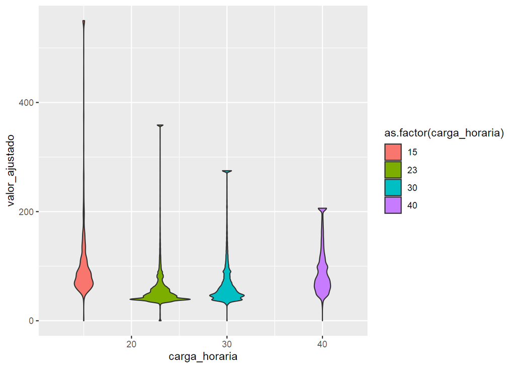

```r
sp_2019 %>%
  mutate(total_pago = gsub("\\.","", total_a_b_c)) %>%
  mutate(total_pago = gsub(",","\\.", total_pago)) %>%
  mutate(total_pago = as.numeric(total_pago)) %>%
  mutate(valor_hora = total_pago/(carga_horaria*4)) %>%
  mutate(valor_ajustado = ifelse(total_pago > 33000, 33000/(carga_horaria*4), valor_hora)) %>%
  ggplot(aes(x=carga_horaria, y=valor_ajustado, fill=as.factor(carga_horaria))) +
  geom_violin()
```

# 5. Há “outliers” na periferia? Quais são?

Para identificar as escolas geograficamente periféricas, vamos calcular a distância euclidiana de cada escola até a Praça da Sé (centro geográfico de Sâo Paulo).

```r
escolas_dist <- escolas_com_cod %>%
  mutate(dif_lat = as.numeric(latitude) + 23.550531400378656,
         dif_long = as.numeric(longitude)  + 46.633829132143376,
         dist_eucli = sqrt((dif_lat^2) + (dif_long^2)))
```

Agora vamos listar os outliers, tanto com base na média da hora quanto na mediana

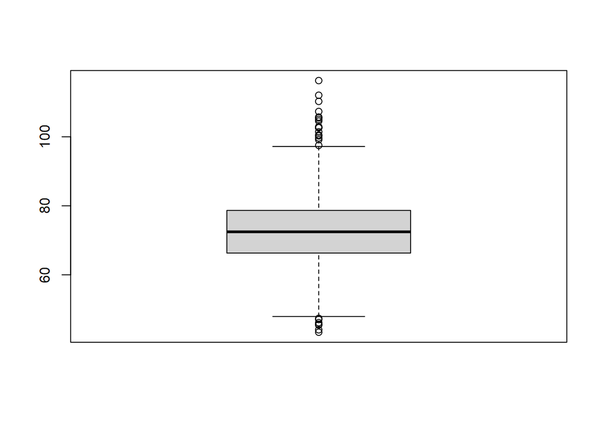

```r
out_medias <- boxplot(escolas_dist$media_hora_anual)$out
```

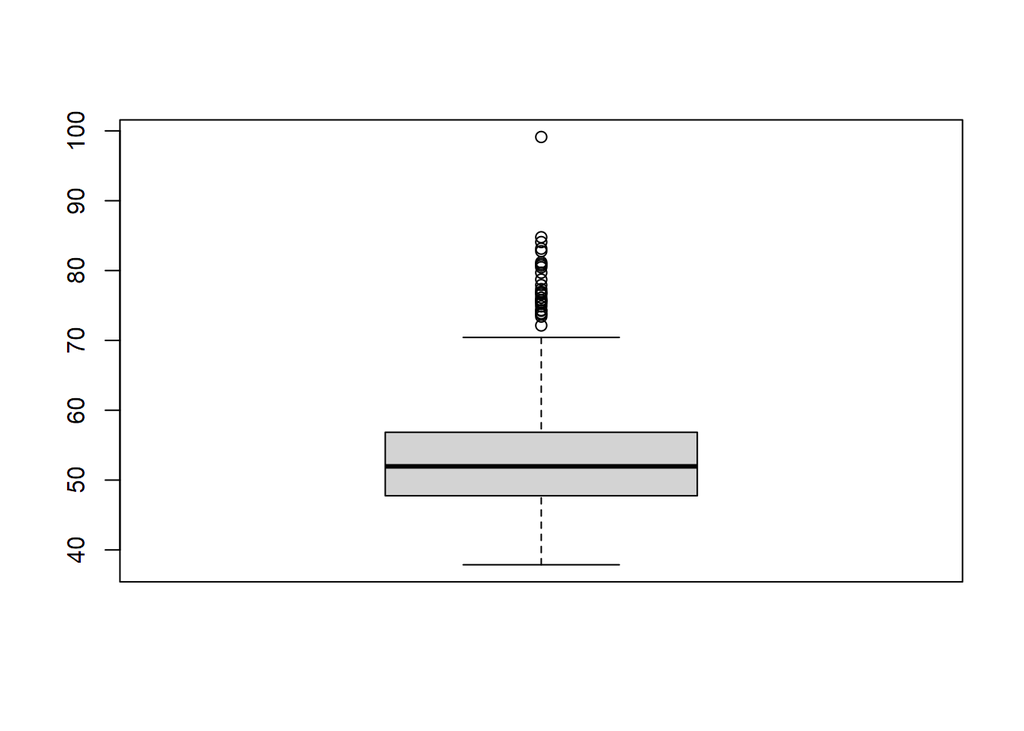

```r
out_medianas <- boxplot(escolas_dist$mediana_hora_anual)$out
```

Outliers com base na mediana da hora cuja distância euclidiana do centro é maior que 0.07

```r
escolas_dist %>%
  filter(dist_eucli > 0.07 & mediana_hora_anual %in% out_medianas)
```

| codigo_do_local_de_exercicio | local_de_exercicio | mediana_hora_anual | media_hora_anual | media_15 | media_23 | media_30 | media_40 | media_hora_real | cat_lic | cat_med | cat_ped | cat_efet | cat_nao | cod_escola | latitude | longitude | distrito | coddist | media | nd | bra | pre | par | ama | ind | total | ppi_prop | ppi_prop_declarados | dif_lat | … |
| --- | --- | --- | --- | --- | --- | --- | --- | --- | --- | --- | --- | --- | --- | --- | --- | --- | --- | --- | --- | --- | --- | --- | --- | --- | --- | --- | --- | --- | --- | --- |
| 000000202499 | EMEI NIDA MALDI CORAZZA EDUCADORA | 73.87708 | 90.08594 | 0.0000000 | 3.468750 | 11.000000 | 3.000000 | 110.02714 | 0 | 0 | 15 | 2 | 0 | 35051627 | -23.573295 | -46.761251 | RIO PEQUENO | 67 | 2.273077 | 110 | 68 | 7 | 57 | 1 | 0 | 243 | 71.60494 | 48.12030 | -0.0227636 | … |
| 000000202525 | EMEI LOURDES HEREDIA MELLO PROFA | 73.40900 | 88.87348 | 0.0000000 | 2.695652 | 7.739130 | 3.000000 | 97.21623 | 0 | 0 | 12 | 2 | 0 | 35051883 | -23.630764 | -46.643579 | JABAQUARA | 38 | 2.383292 | 35 | 48 | 15 | 17 | 1 | 0 | 116 | 57.75862 | 39.50617 | -0.0802326 | … |
| 000000202562 | EMEI ANHANGUERA | 83.13662 | 100.52444 | 0.0000000 | 5.837963 | 9.171296 | 3.000000 | 111.88033 | 0 | 0 | 18 | 1 | 0 | 35052255 | -23.662108 | -46.68634 | CAMPO GRANDE | 16 | 1.752874 | 9 | 132 | 8 | 31 | 0 | 0 | 180 | 26.66667 | 22.80702 | -0.1115766 | … |
| 000000202572 | EMEI VIRIATO CORREIA | 76.58362 | 85.38870 | 0.0000000 | 8.430894 | 11.223577 | 2.841463 | 91.92132 | 0 | 0 | 19 | 1 | 0 | 35052358 | -23.691392 | -46.703569 | SOCORRO | 79 | 1.928571 | 126 | 100 | 2 | 79 | 0 | 0 | 307 | 67.42671 | 44.75138 | -0.1408606 | … |
| 000000202580 | EMEI SILVIO ROMERO | 78.71437 | 95.71303 | 0.0000000 | 2.881481 | 5.562963 | 2.837037 | 105.30955 | 1 | 0 | 9 | 2 | 0 | 35052437 | -23.529485 | -46.559839 | TATUAPE | 80 | 1.659091 | 57 | 32 | 3 | 21 | 1 | 2 | 116 | 71.55172 | 44.06780 | 0.0210464 | … |
| 000000202587 | EMEI GINA DE MARTINO DRA | 84.07900 | 97.50997 | 0.0000000 | 3.612903 | 11.456221 | 3.082949 | 114.98961 | 0 | 0 | 16 | 2 | 0 | 35052504 | -23.478197 | -46.626536 | MANDAQUI | 51 | 2.016854 | 130 | 83 | 5 | 20 | 10 | 0 | 248 | 62.50000 | 21.18644 | 0.0723344 | … |
| 000000202832 | EMEF QUEIROZ FILHO PROF | 75.74000 | 102.66802 | 0.3587896 | 17.716138 | 34.907781 | 5.089337 | 119.99271 | 35 | 0 | 25 | 3 | 0 | 35054987 | -23.597505 | -46.565779 | VILA PRUDENTE | 93 | 2.124224 | 239 | 593 | 30 | 286 | 14 | 4 | 1166 | 47.94168 | 34.51996 | -0.0469736 | … |
| 000000204376 | EMEI EDER SADER | 75.74242 | 105.49758 | 0.0000000 | 7.186813 | 5.000000 | 3.000000 | 127.98997 | 1 | 0 | 11 | 2 | 0 | 35076156 | -23.617291 | -46.493786 | SAPOPEMBA | 76 | 3.228346 | 80 | 54 | 1 | 11 | 0 | 1 | 147 | 63.26531 | 19.40299 | -0.0667596 | … |
| 000000204990 | EMEI MANOEL FIEL FILHO | 80.73513 | 95.64059 | 0.0000000 | 3.273171 | 10.843902 | 3.000000 | 104.35819 | 0 | 0 | 17 | 2 | 0 | 35085571 | -23.624858 | -46.469605 | SAO RAFAEL | 75 | 3.610000 | 87 | 89 | 2 | 39 | 0 | 0 | 217 | 58.98618 | 31.53846 | -0.0743266 | … |
| 000000205602 | EMEI CLARA NUNES | 80.46557 | 89.82766 | 1.0000000 | 9.483395 | 11.236162 | 3.000000 | 104.58053 | 0 | 2 | 23 | 2 | 0 | 35092848 | -23.683261 | -46.710892 | SOCORRO | 79 | 1.928571 | 127 | 105 | 1 | 60 | 1 | 0 | 294 | 63.94558 | 36.52695 | -0.1327296 | … |

[output cut: 6 more lines]

Entre essas escolas, a EMEI MANOEL FIEL FILHO se destaca com o maior IPVS (3,6) em São Rafael.

```r
escolas_dist %>%
  filter(dist_eucli > 0.07 & media_hora_anual %in% out_medias)
```

| codigo_do_local_de_exercicio | local_de_exercicio | mediana_hora_anual | media_hora_anual | media_15 | media_23 | media_30 | media_40 | media_hora_real | cat_lic | cat_med | cat_ped | cat_efet | cat_nao | cod_escola | latitude | longitude | distrito | coddist | media | nd | bra | pre | par | ama | ind | total | ppi_prop | ppi_prop_declarados | dif_lat | … |
| --- | --- | --- | --- | --- | --- | --- | --- | --- | --- | --- | --- | --- | --- | --- | --- | --- | --- | --- | --- | --- | --- | --- | --- | --- | --- | --- | --- | --- | --- | --- |
| 000000202516 | EMEI IGNACIO HENRIQUE ROMEIRO PROF | 64.87400 | 105.02861 | 0.0000000 | 3.000000 | 7.084416 | 2.759740 | 128.50350 | 0 | 0 | 11 | 2 | 0 | 35051792 | -23.609684 | -46.671306 | MOEMA | 32 | 1.011364 | 6 | 61 | 2 | 42 | 0 | 1 | 112 | 45.53571 | 42.45283 | -0.0591526 | … |
| 000000202562 | EMEI ANHANGUERA | 83.13662 | 100.52444 | 0.0000000 | 5.837963 | 9.171296 | 3.000000 | 111.88033 | 0 | 0 | 18 | 1 | 0 | 35052255 | -23.662108 | -46.68634 | CAMPO GRANDE | 16 | 1.752874 | 9 | 132 | 8 | 31 | 0 | 0 | 180 | 26.66667 | 22.80702 | -0.1115766 | … |
| 000000202587 | EMEI GINA DE MARTINO DRA | 84.07900 | 97.50997 | 0.0000000 | 3.612903 | 11.456221 | 3.082949 | 114.98961 | 0 | 0 | 16 | 2 | 0 | 35052504 | -23.478197 | -46.626536 | MANDAQUI | 51 | 2.016854 | 130 | 83 | 5 | 20 | 10 | 0 | 248 | 62.50000 | 21.18644 | 0.0723344 | … |
| 000000202832 | EMEF QUEIROZ FILHO PROF | 75.74000 | 102.66802 | 0.3587896 | 17.716138 | 34.907781 | 5.089337 | 119.99271 | 35 | 0 | 25 | 3 | 0 | 35054987 | -23.597505 | -46.565779 | VILA PRUDENTE | 93 | 2.124224 | 239 | 593 | 30 | 286 | 14 | 4 | 1166 | 47.94168 | 34.51996 | -0.0469736 | … |
| 000000204376 | EMEI EDER SADER | 75.74242 | 105.49758 | 0.0000000 | 7.186813 | 5.000000 | 3.000000 | 127.98997 | 1 | 0 | 11 | 2 | 0 | 35076156 | -23.617291 | -46.493786 | SAPOPEMBA | 76 | 3.228346 | 80 | 54 | 1 | 11 | 0 | 1 | 147 | 63.26531 | 19.40299 | -0.0667596 | … |
| 000000539810 | CEI DIRET VELEIROS | 37.97975 | 45.43999 | 0.0000000 | 0.000000 | 25.738854 | 2.815287 | 47.35375 | 0 | 1 | 27 | 1 | 0 | 35239203 | -23.685094 | -46.711829 | SOCORRO | 79 | 1.928571 | 2 | 83 | 1 | 51 | 0 | 0 | 137 | 39.41606 | 38.51852 | -0.1345626 | … |
| 000000587241 | CIEJA ROSA KAZUE INAKAKE DE SOUZA PROFA | 76.96437 | 99.16864 | 0.0000000 | 2.749196 | 23.228296 | 0.000000 | 126.51260 | 15 | 0 | 7 | 0 | 0 | 35256500 | -23.544195 | -46.415413 | GUAIANASES | 31 | 3.467836 | 273 | 432 | 147 | 612 | 3 | 2 | 1469 | 70.38802 | 63.62876 | 0.0063364 | … |
| 000000612327 | CIEJA ROSE MARY FRASSON PROFA | 77.34158 | 99.67465 | 0.0000000 | 3.873786 | 21.941748 | 0.000000 | 119.48019 | 17 | 0 | 9 | 0 | 0 | 35259731 | -23.477017 | -46.681467 | BRASILANDIA | 11 | 3.348649 | 70 | 393 | 108 | 356 | 0 | 0 | 927 | 57.60518 | 54.14236 | 0.0735144 | … |
| 000000612697 | CIEJA ALUNA JESSICA NUNES HERCULANO | 75.48013 | 104.55991 | 0.0000000 | 0.081250 | 26.593750 | 0.000000 | 127.98550 | 19 | 0 | 7 | 0 | 0 | 35260228 | -23.575351 | -46.716556 | BUTANTA | 12 | 1.500000 | 107 | 421 | 76 | 340 | 6 | 1 | 951 | 55.09989 | 49.40758 | -0.0248196 | … |
| 000000643309 | CEI DIRET ALICE APARECIDA DE SOUZA PROFA | 38.42533 | 45.67090 | 0.0000000 | 0.000000 | 24.245955 | 3.906149 | 50.93201 | 1 | 1 | 25 | 1 | 1 | 35282339 | -23.599849 | -46.392965 | CIDADE TIRADENTES | 25 | 3.734139 | 48 | 39 | 7 | 25 | 1 | 0 | 120 | 66.66667 | 44.44444 | -0.0493176 | … |

[output cut: 6 more lines]

Para as escolas outliers na média da hora paga, se destcam aquelas localizadas em Jardim Angela, com 4 outliers nesse distrito.

# 6. Há distribuição diferente por etapa de ensino? Ex.: professores de CEI já têm garantida a jornada integral, ao contrário dos demais (e os da etapa final do EF têm mais dificuldade de alcançá-la).

```r
escolas_com_class <- escolas_dist %>%
  mutate(etapa = case_when(grepl(local_de_exercicio, "^EMEI") ~ "EMEI",
         grepl("^CEI", local_de_exercicio) ~ "CEI",
         grepl("^CEMEI", local_de_exercicio) ~ "CEMEI",
         grepl("^CEU CEI", local_de_exercicio) ~ "CEU CEI",
         grepl("^CEU EMEI", local_de_exercicio) ~ "CEU EMEI",
         grepl("^CEU EMEF", local_de_exercicio) ~ "CEU EMEF",
         grepl("^CIEJA", local_de_exercicio) ~ "CIEJA",
         grepl("^EMEF", local_de_exercicio) ~ "EMEF",
         grepl("^EMEI", local_de_exercicio) ~ "EMEI"))
```

Distribuição da média das horas anuais de acordo com a etapa de cada escola. Cada observação representação uma escola.

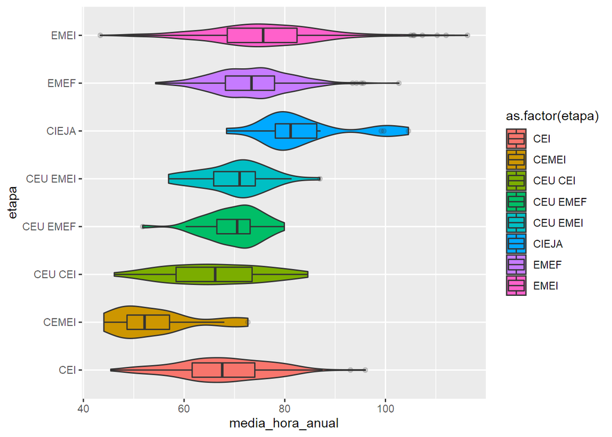

```r
escolas_com_class%>%
  ggplot(aes(x=etapa, y=media_hora_anual, fill=as.factor(etapa))) +
  geom_violin() +
  geom_boxplot(width = 0.3, alpha=0.2) +
  coord_flip()
```

Distribuição da mediana das horas anuais de acordo com a etapa de cada escola. Cada observação representação uma escola.

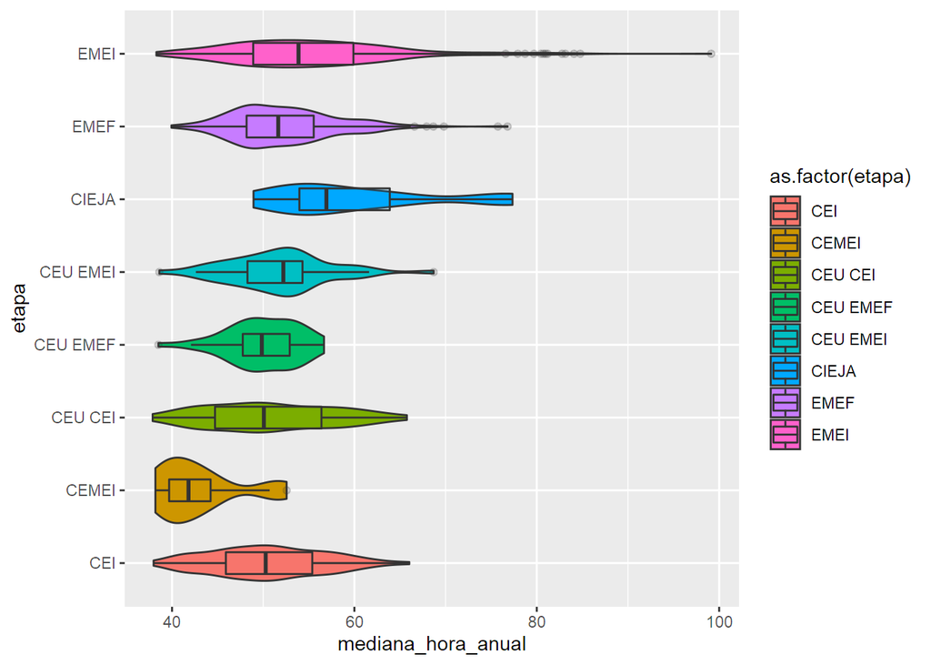

```r
escolas_com_class%>%
  ggplot(aes(x=etapa, y=mediana_hora_anual, fill=as.factor(etapa))) +
  geom_violin() +
  geom_boxplot(width = 0.3, alpha=0.2) +
  coord_flip()
```

É possível notar que os CIEJAS se destacam com valores mais altos, tanto na média quanto na mediana, enquanto os CEMEIS se destacam com os valores mais baixos. Comparando EMEF com EMEI, no entanto, não parece ter diferenças substanciais na média, apesar de EMEIS possuírem escolas com médias mais altas.